# c04 · Shiny Apps

Advanced R for Data Analysis and Reporting

Johann-Friedrich Salzmann

## What’s in this module

- What Shiny is (and isn’t) for
- Structure: UI, server, one vs. two files
- Inputs, outputs, layout
- Reactivity
- Deployment

## The goal

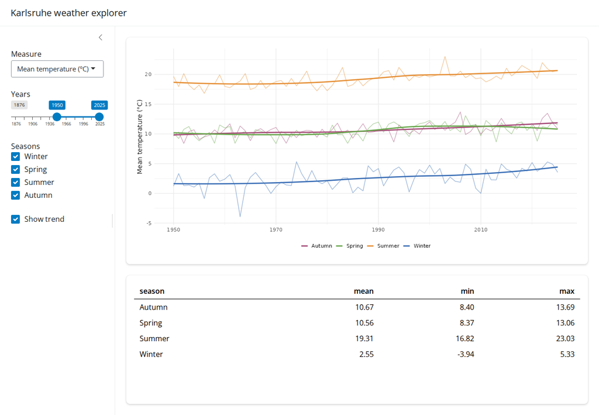

## Shiny: rationale, capabilities, limits

- Interactive web apps from R code, no HTML/JavaScript
- Good for: exploring data with non-coders, dashboards, teaching tools
- Limits: needs a running R server per user; not for high-traffic public sites
- Static result? Then a Quarto report is simpler

## Basic structure

```r
ui <- page_sidebar(              # frontend: what the user sees
  sidebar = sidebar(sliderInput("n", "Days", min = 10, max = 1000, value = 100)),
  plotOutput("histogram")
)

server <- function(input, output) {   # backend: what R computes
  output$histogram <- renderPlot({
    tibble(temp = rnorm(input$n, mean = 10, sd = 8)) |>
      ggplot(aes(x = temp)) +
      geom_histogram(bins = 30)
  })
}

shinyApp(ui, server)
```

## One file vs. two files

- `app.R`: ui + server + `shinyApp()`: our default
- `ui.R` + `server.R` (+ `global.R`, run first automatically): for larger apps
- Both: `shiny::runApp("c04/app")` or *Run App* in Positron

## Inputs and outputs

| Inputs | Outputs |
| --- | --- |
| `selectInput()` | `plotOutput()` + `renderPlot()` |
| `sliderInput()` | `tableOutput()` + `renderTable()` |
| `checkboxInput()`, `checkboxGroupInput()` | `textOutput()` + `renderText()` |
| `radioButtons()`, `dateRangeInput()` | `plotlyOutput()` + `renderPlotly()` |

Every input: an **ID**, a **label**, choices. Read with `input$ID`.

## Reactivity

- The server is **not** run top to bottom
- Each `render*()` re-runs when an `input$...` it uses changes, and only then
- `reactive()`: a shared data pipeline, computed once, used by several outputs

```r
seasonal <- reactive({
  weather |>
    filter(year(date) >= first(input$years), season %in% input$seasons)
})

output$trend_plot <- renderPlot({ seasonal() |> ggplot(...) })
output$summary_table <- renderTable({ seasonal() |> summarize(...) })
```

## Deployment

- [**Posit Connect Cloud**](https://connect.posit.cloud), [**shinyapps.io**](https://www.shinyapps.io): free tiers, `rsconnect::deployApp()`
- [**Shinylive**](https://posit-dev.github.io/r-shinylive/): runs in the browser via WebAssembly, static hosting (GitHub Pages)
- **Own server**: Shiny Server, Docker

## Practice

- `c04/c04_classroom.R`, the app in `c04/app/app.R`
- Try it: extend the app; build your own